# The Future of the Hemlocks: Comparing the Hemlock and Black Birch Forests

Some Smith Students

December 16, 2015

```r
macleish <- read.csv("HemlockData.csv - group-AnnaBaileyEmmaMaddie-data.csv.csv", header=TRUE, skip=1)
names(macleish) <- c("ForestType", "Plot", "SurveyPoint", "LayerDepth", "DryMass", "CNcontent", "Mites")
require(mosaic)
require(dplyr)
```

##### ABSTRACT

The hemlock forests of New England are a vital resource, both economically and ecologically, but they are currently under attack from two invasive species of insects. Within the next few decades, they will all be dead, leaving an entirely different forest of predominantly black birch trees in their place. We want to know whether the transition from one forest type to another will affect the carbon storage ability of the New England forest and thus the rate of climate change. We found that the differences in organic layer depth, organic layer dry mass, and the carbon to nitrogen ratio were significant, indicating that the hemlock forest decomposes organic matter slower and is a better carbon sink than black birch forests. Because black birch forests are on the way in, our analysis suggests that this transition may contribute to greater amounts of carbon in the atmosphere, and, by extension, to more rapid climate change.

##### INTRODUCTION

In New England there is one principal type of forest–the hemlock-dominated. These trees are a vital part of the ecosystem, as they shade out much of the forest floor and provide the majority of the leaf litter (Zukswert et al., 2014). However, due to the introduction of two invasive species, the elongate hemlock scale, which arrived from Asia to the U.S. in 1908, and the hemlock wooly adelgid, which arrived in the 1950s, the hemlock trees are slowing dying out. These insects are slowly spreading throughout New England. Eventually, all of the hemlocks will be replaced by other kinds of trees. Here in Western Massachusetts, the successor to the hemlocks has proved to be the black birch tree.

We wanted to better understand the environmental impacts of this transition from hemlock to birch. Because all trees absorb carbon dioxide and release oxygen, forests such as the hemlock-dominated forests serve as valuable carbon sinks, meaning they can help mitigate climate change by storing carbon-containing compounds for an indefinite period of time. In contrast, decomposing material upon forest floors simultaneously releases carbon dioxide, which mitigates to some extent the degree to which a forest acts as a carbon sink. These counteracting effects vary depending on the composition of the forest floor, which is naturally different for each forest type.

In this observational study, we examined data on the organic layer depth, organic layer soil dry mass, carbon to nitrogen ratio, and number of mites living on the forest floors of both hemlock and black birch plots in order to see if there is a difference between the rates of decomposition. We investigated this question using the following hypotheses:

Null: There is no difference between hemlock and black birch forests in respect to mites, organic layer depth, dry mass, or carbon to nitrogen ratio. Any difference that appears is due to chance.

Alternative: There is a significant difference between hemlock and black birch forests in respect to mites, organic layer depth, dry mass, or the carbon to nitrogen ratio.

If the spreading black birch forests show significantly less decomposition than the disappearing hemlock forests, this could potentially help to slow climate change. On the other hand, if our data suggests that more decomposition tends to occur in the new black birch forests, this indicates that they will actually absorb less carbon overall than their predecessors, potentially increasing the rate of climate change in the years ahead.

##### DATA

```r
head(macleish)
```

```
##   ForestType  Plot SurveyPoint LayerDepth DryMass CNcontent  Mites
## 1    Hemlock Plot1           1        2.5  1031.6    26.291 1.4675
## 2    Hemlock Plot1           2        2.5   537.6    23.717 1.1962
## 3    Hemlock Plot1           3        4.0   858.8    26.424 1.8094
## 4    Hemlock Plot1           4        3.5   660.0    24.941 1.1111
## 5    Hemlock Plot1           5        2.0  1021.2    23.922 1.3126
## 6    Hemlock Plot1           6        4.0  1116.0    24.978 0.3836
```

The variables in this data set include one categorical explanatory variable, the forest type (hemlock or black birch), and four numerical response variables: mites, measured in mites per gram dried soil organic matter; organic layer depth, measured in centimeters; soil organic layer dry mass, measured in grams per squared meters, and carbon to nitrogen ratio of soil organic matter. The mite count is a measure of how many mites are found in each gram of dried organic matter; organic layer depth is a measurement of the depth of decomposing material on the forest floor; dry mass is a measurement of the mass of the organic layer samples after they have been dried and the carbon to nitrogen ratio is the mass of carbon compared to the mass of nitrogen in the organic layer. We did not have to eliminate any of our data from consideration.

The population from which we sampled was a set of randomly selected 10 m x 15 m plots of land from the hemlock and black birch forest areas of Smith College’s Macleish Field Station. Three plots of land were selected within each of type of forest, and ten squares of earth (900 cm squared each) were randomly chosen within each of these larger plots. The organic layer soil within the smaller plots (of which there were thus 30 for each type of forest, or 60 in total) was removed and analyzed for mites, organic layer depth, organic layer soil dry mass, or number of mites. Importantly, the data are not paired - they were collected from different samples at different times over the past 3-4 years. In others words, there are 10 observations per plot for each variable, but those data are not drawn from the same sample.

Because the data for one variable are not paired with data from another variable, we are unable to see if there are associations among the variables by doing a multiple regression. In addition, we wanted to see whether the forest type could predict the other variables (number of mites, etc.) not the other way around. Thus, we decided to do hypothesis tests for each of our variables. In order to counteract the problem of multiple comparisons, we used Bonferroni’s correction. Since we tested four hypotheses at an α = 0.05, the Bonferroni correction tested each individual hypothesis at 0.0125.

##### MITES

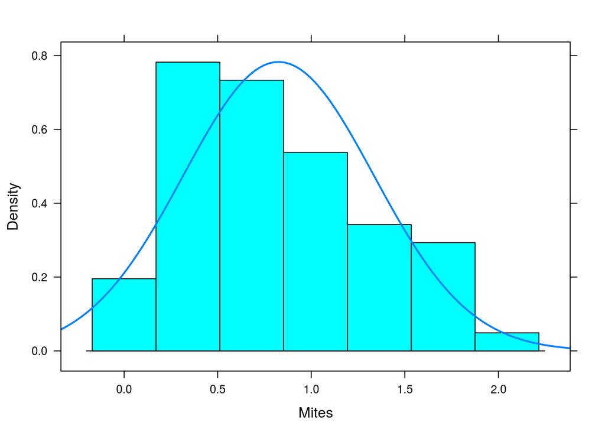

```r
histogram(~Mites, data = macleish, fit = "normal")
```

```r
macleish %>%
group_by(ForestType) %>%
summarize(mean(Mites))
```

```
## Source: local data frame [2 x 2]
##
##   ForestType mean(Mites)
## 1      Birch   0.8789800
## 2    Hemlock   0.7719233
```

```r
mites_stats <- favstats(Mites~ForestType, data=macleish)
mites_compare <- mites_stats %>%
  summarize(diff = diff(mean), se = sqrt(sum(sd^2/n)), df = min(n - 1))
mites_compare <- mites_compare %>%
mutate(t = (diff - 0) / se) %>%
mutate(p_value = 2 * pt(t, df = df))
mites_compare
```

```
##         diff        se df         t  p_value
## 1 -0.1070567 0.1330925 29 -0.804378 0.427724
```

We would expect that the more decomposition that occurs on a forest floor, the more mites, which feed on rotting matter, would be found in that soil. Although the mean mite count for the hemlock and birch forests did slightly vary–the birch had a mean count 0.88 mites per gram of organic soil matter, and the hemlock had a count of 0.77 mites per gram of organic soil matter–we found that that difference in means, with a p-value of 0.427724, was far from statistically significant. Thus our data did not provide sufficient evidence for any real difference between mite count in the soils of each forest type.

##### LAYER DEPTH

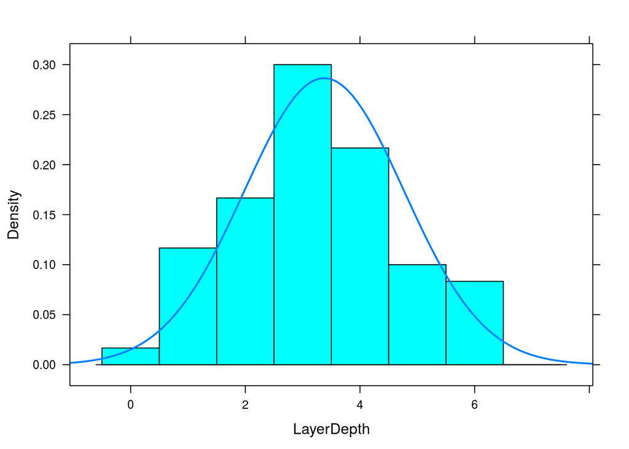

```r
histogram(~LayerDepth, data = macleish, fit = "normal")
```

```r
macleish %>%
group_by(ForestType) %>%
summarize(mean(LayerDepth))
```

```
## Source: local data frame [2 x 2]
##
##   ForestType mean(LayerDepth)
## 1      Birch         2.483333
## 2    Hemlock         4.266667
```

```r
laydepthcontent_stats <- favstats(LayerDepth ~ ForestType, data = macleish)
laydepthcompare <- laydepthcontent_stats %>%
  summarize(diff = diff(mean), se = sqrt(sum(sd^2/n)), df = min(n - 1))
laydepthcompare <- laydepthcompare %>%
mutate(t = (diff - 0) / se) %>%
mutate(p_value = 2 * pt(t, df = df, lower.tail=FALSE))
laydepthcompare
```

```
##       diff        se df        t      p_value
## 1 1.783333 0.2808205 29 6.350439 6.118674e-07
```

Concerning organic layer depth, we found the difference in means to be statistically significant because we calculated a very low p-value of 6.118674e-07, far lower than the significance value of 0.0125. Birch forests have a mean organic layer depth of 2.48 cm, and hemlock forests have a mean of 4.27 cm. The organic layer is a measurement of the depth of decomposing material on the forest floor. Thus, on average, hemlock forests have a greater organic layer depth than birch forests, meaning that the organic matter decomposes slower in hemlock forests than birch.

##### DRY MASS

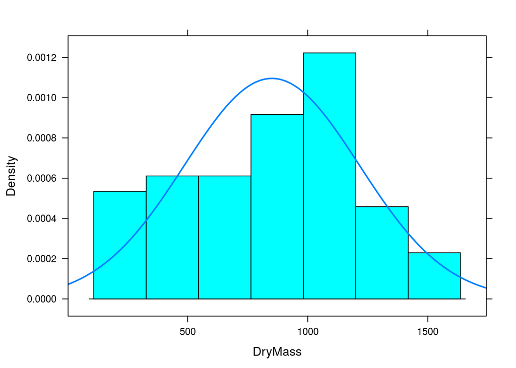

```r
histogram(~DryMass, data = macleish, fit = "normal")
```

```r
macleish %>%
group_by(ForestType) %>%
summarize(mean(DryMass))
```

```
## Source: local data frame [2 x 2]
##
##   ForestType mean(DryMass)
## 1      Birch       611.680
## 2    Hemlock      1089.893
```

```r
mass_stats <- favstats(DryMass ~ ForestType, data = macleish)
mass_compare <- mass_stats %>%
  summarize(diff = diff(mean), se = sqrt(sum(sd^2/n)), df = min(n - 1))
mass_compare <- mass_compare %>%
mutate(t = (diff - 0) / se) %>%
mutate(p_value = 2 * pt(t, df = df, lower.tail=FALSE))
mass_compare
```

```
##       diff       se df        t      p_value
## 1 478.2133 72.07774 29 6.634689 2.838091e-07
```

When analyzing dry mass, we also found the difference in means to be statistically significant, as evidenced by the calculated p-value of 2.838091e-07. Even with the lowered significance level of 0.0125, the p-value of dry mass remains significant. Birch forests have a mean dry mass of 611. 68 g/m2 and hemlocks have a mean dry mass of 1089.89 g/m2. Thus, on average, hemlock forests have a greater dry mass than birch forests. Contextually, this means that there is more plant matter decomposing in hemlock forests and therefore, hemlock forests decompose organic matter slower than birch forests do.

##### CARBON : NITROGEN RATIO

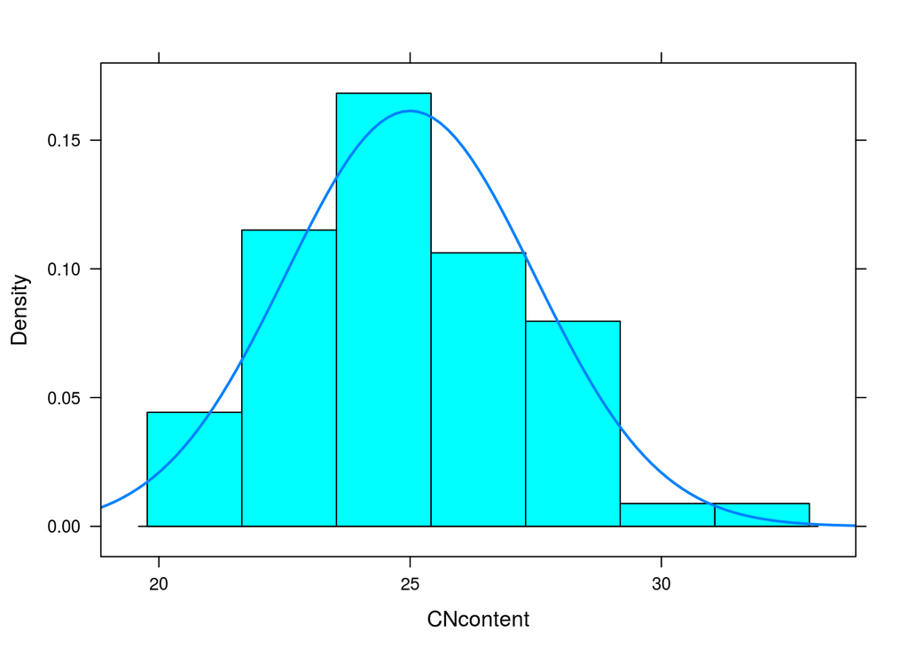

```r
histogram(~CNcontent, data = macleish, fit = "normal")
```

```r
macleish %>%
group_by(ForestType) %>%
summarize(mean(CNcontent))
```

```
## Source: local data frame [2 x 2]
##
##   ForestType mean(CNcontent)
## 1      Birch        23.53957
## 2    Hemlock        26.45617
```

```r
CNcontent_stats <- favstats(CNcontent ~ ForestType, data = macleish)
CNcontent_compare <- CNcontent_stats %>%
summarize(diff = diff(mean), se = sqrt(sum(sd^2/n)), df = min(n - 1)) %>%
mutate(t = (diff - 0) / se) %>%
mutate(p_value = 2 * pt(t, df = df, lower.tail = FALSE))
CNcontent_compare
```

```
##     diff        se df        t      p_value
## 1 2.9166 0.5241954 29 5.563956 5.299795e-06
```

In respect to the carbon to nitrogen ratio, we found the difference in means to be statistically significant as well, as evidenced by the calculated p-value of 5.299795 e-06, which is far lower than the significance level of 0.0125. Birch forests have a mean carbon to nitrogen ratio of 23.54, while hemlock forests have a mean carbon to nitrogen ratio of 26.46. Thus, on average, hemlock forests have a higher mean carbon to nitrogen ratio than black birch, which indicates that hemlock forests decompose organic layer slower than black birch forests.

##### CONCLUSION

In our study, we sought to understand the differences between hemlock and black birch forests and to investigate which variables would be significant in modelling what changes will occur once the black birch becomes the dominant tree. By interpreting these changes, we can infer what effect–if any–the transition from one dominant tree to the other will have on climate change. Through a series of hypothesis tests, we were able to find the statistical significance of each variable. We found that organic layer depth, organic layer dry mass, and carbon to nitrogen ratio were significant while mites were not.

According to our models, forest type affects organic layer depth, organic layer dry mass, and carbon to nitrogen ratio in the forest floor. The fact that hemlock forests have significantly deeper organic layers and greater organic layer dry mass means that there is a slower decomposition rate in hemlock forests. A greater accumulation of decaying organic materials in the forest floor indicates that the hemlock forest can hold more carbon than the birch forest, making it a superior carbon sink. The hemlocks’ higher carbon to nitrogen ratio also indicates that there will be slower decomposition, because the soil chemistry is not ideal. Each of these variables individually, and especially when taken together, suggest that hemlock forests are a superior carbon sink compared to black birch forests. This is a discouraging finding, since hemlock forests are currently being killed off by invasive species of insects, to be replaced by a forest that will not keep as much carbon out of the atmosphere. This may increase the rates of climate change.

##### REFERENCES

[1]. Bellemare, personal communication, October 22, 2015

[2]. Bellemare, personal communication, December 12, 2015

[3]. “Elongate Hemlock Scale.” Department of Entomology. Penn State University, Oct. 2009. Web. 16 Dec. 2015.

[4]. Zukswert, J. M., Bellemare, J., Rhodes, A. L., Sweezy, T., Gallogly, M., Acevedo, S., & Taylor, R. S. (2014). Forest Community Structure Differs, but not Ecosystem Processes, 25 Years after Eastern Hemlock Removal in an Accidental Experiment. Southeastern Naturalist, 13(6), 61-87.